# Reproducible Research: Peer Assessment 1

## Loading and preprocessing the data

```r
data = read.csv("activity/activity.csv")
str(data)
```

```
'data.frame':   17568 obs. of  3 variables:
 $ steps   : int  NA NA NA NA NA NA NA NA NA NA ...
 $ date    : Factor w/ 61 levels "2012-10-01","2012-10-02",..: 1 1 1 1 1 1 1 1 1 1 ...
 $ interval: int  0 5 10 15 20 25 30 35 40 45 ...
```

## What is mean total number of steps taken per day?

1.Calculate the total number of steps taken per day

```r
attach(data)
s = tapply(steps, date, function(x) {
    sum(x, na.rm = T)
})
s
```

```
2012-10-01 2012-10-02 2012-10-03 2012-10-04 2012-10-05 2012-10-06
         0        126      11352      12116      13294      15420
2012-10-07 2012-10-08 2012-10-09 2012-10-10 2012-10-11 2012-10-12
     11015          0      12811       9900      10304      17382
2012-10-13 2012-10-14 2012-10-15 2012-10-16 2012-10-17 2012-10-18
     12426      15098      10139      15084      13452      10056
2012-10-19 2012-10-20 2012-10-21 2012-10-22 2012-10-23 2012-10-24
     11829      10395       8821      13460       8918       8355
2012-10-25 2012-10-26 2012-10-27 2012-10-28 2012-10-29 2012-10-30
      2492       6778      10119      11458       5018       9819
2012-10-31 2012-11-01 2012-11-02 2012-11-03 2012-11-04 2012-11-05
     15414          0      10600      10571          0      10439
2012-11-06 2012-11-07 2012-11-08 2012-11-09 2012-11-10 2012-11-11
      8334      12883       3219          0          0      12608
2012-11-12 2012-11-13 2012-11-14 2012-11-15 2012-11-16 2012-11-17
     10765       7336          0         41       5441      14339
2012-11-18 2012-11-19 2012-11-20 2012-11-21 2012-11-22 2012-11-23
     15110       8841       4472      12787      20427      21194
2012-11-24 2012-11-25 2012-11-26 2012-11-27 2012-11-28 2012-11-29
     14478      11834      11162      13646      10183       7047
2012-11-30
         0
```

2.Make a histogram of the total number of steps taken each day

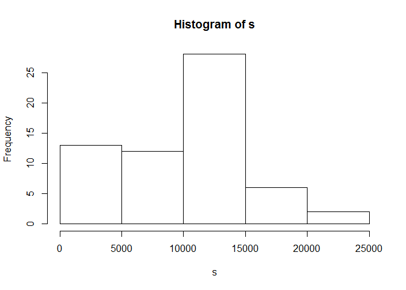

```r
hist(s)
```

3.Calculate and report the mean and median of the total number of steps taken per day

```r
mean(s)
```

```
[1] 9354.23
```

```r
median(s)
```

```
[1] 10395
```

## What is the average daily activity pattern?

1.Make a time series plot of the 5-minute interval (x-axis) and the average number of steps taken, averaged across all days (y-axis)

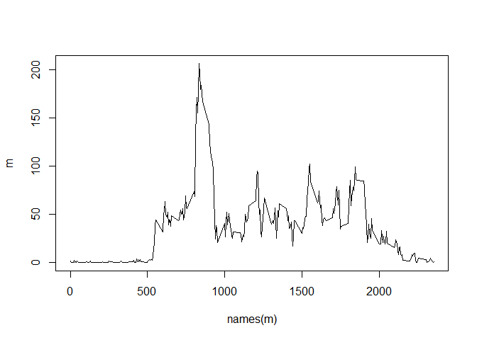

```r
m = tapply(steps, interval, function(x) {
    mean(x, na.rm = T)
})
plot(names(m), m, type = "l")
```

2.Which 5-minute interval, on average across all the days in the dataset, contains the maximum number of steps?

```r
m[which.max(m)]
```

```
     835
206.1698
```

We can see the interval of 835 contains the maximum number of steps which is 206.2.